# Population statistics

J. Ignacio Lucas Lledó

2025-06-12

## Nucleotide diversity from the SFS

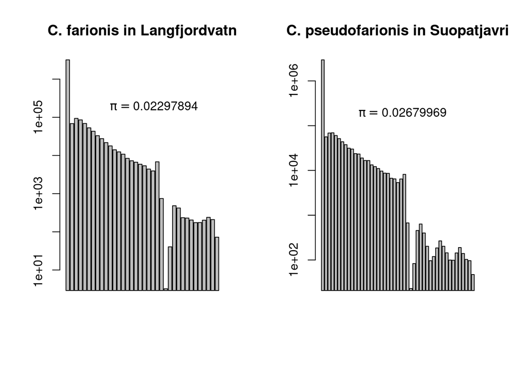

```r
PiTajima <- function(x, folded = TRUE){
   n <- length(x) - 1  # the SFS includes invariable sites and 0 values for i > n/2
   a <- 1:(n/2)
   Theta <- (2/(n * (n-1))) * sum(x[2:(n/2 + 1)] * a * (n - a)) / sum(x)
   return(Theta)
}
# Those SFSs were obtained from alignments to RAD loci, I think.
Lan.sfs <- scan('../2024-10-10/SFS/Langfjordvatn.sfs', quiet = TRUE)
Suo.sfs <- scan('../2024-10-10/SFS/Suopatjavri.sfs',   quiet = TRUE)
Lan.n <- length(Lan.sfs) - 1
Suo.n <- length(Suo.sfs) - 1
Lan.pi <- PiTajima(Lan.sfs)
Suo.pi <- PiTajima(Suo.sfs)
par(mfrow=c(1,2))
barplot(Lan.sfs[1:(1 + Lan.n / 2)], main = 'C. farionis in Langfjordvatn', log = 'y')
text(25, 2.0e+05, bquote(pi==.(Lan.pi)))
barplot(Suo.sfs[1:(1 + Suo.n / 2)], main = 'C. pseudofarionis in Suopatjavri', log = 'y')
text(30, 2.0e+05, bquote(pi==.(Suo.pi)))
```

Both SFSs show a deficit of singletons, which must be due to missed heterozygous sites or confusion of singletons with sequencing errors. They showed an excess of high frequency SNPs, before filtering sites not in HWE. After filtering, the drop in mid-frequency SNPs appeared.

Filtering sites not in HWE removes (all?) collapsed paralogous sites, which is necessary. However, it could affect our capacity to estimate inbreeding coefficients, at least per site. Certainly, if I remove sites not in HWE, I cannot expect to find sites out of HWE afterwards. But the point is to estimate inbreeding coefficients per individual, not per site, which should not be affected, unless there was a correlation of inbreeding among individuals. That is, individuals should not be related. Then, the only correlation of inbreeding among individuals would be caused by collapsed paralogous sites, which can be removed without affecting estimates of per individual inbreeding coefficients.

Note that I originally included very low-coverage sites in the estimates. Because I suspected the lack of singletons could be due to such low-coverage sites hiding heterozygotes, I re-estimated the SFSs in the `2024-10-10` folder, using a minimum coverage of 4 per individual, and a minimum number of individuals equal to 4/5 the total number, in each population. The results are essentially the same, with a small increase of heterozygosity.

The SFSs suggest that invariable sites (first category of the SFS) are about 4.56 or 5.32 times more abundant than variable sites, in *C. pseudofarionis* (Suopatjavri) and *C. farionis* (Langfjordvatn), respectively.

Let’s take a look at the admixed individuals.

```bash
ASM=../2023-05-15/assembly.fasta
BAM=../2023-05-18/BAM
# C. farionis only from Langfjordvatn (I exclude S004Cma, S004Cmb, S061Cma and S061Cmb)
if [ ! -e farionis.txt ]; then
   gawk '((NR > 1) && ($3 > 0.95) && ($1 ~ /^L/)){
      print $1
   }' ../2024-10-05/summary.txt | sort > farionis.txt
fi
# C. pseudofarionis only from Suopatjavri (I exclude L131Cmb)
if [ ! -e pseudofarionis.txt ]; then
   gawk '((NR > 1) && ($2 > 0.95) && ($1 ~ /^S/)){
      print $1
   }' ../2024-10-05/summary.txt | sort > pseudofarionis.txt
fi
# Hybrids are L019Cxa, L019Cxb, L088Cma and S023Cxd:
if [ ! -e hybrids.txt ]; then
   gawk '((NR > 1) && ($2 < 0.95) && ($3 < 0.95)){
      print $1
   }' ../2024-10-05/summary.txt | sort > hybrids.txt
fi

for pop in farionis pseudofarionis hybrids; do
   if [ ! -e $pop.toRef.list ]; then
      find $BAM -name '*.bam' | grep -f $pop.txt | sort > $pop.toRef.list
   fi
done

if [ ! -e farionis.sfs ]; then
   ln -s ../2024-10-10/SFS/Langfjordvatn.sfs farionis.sfs
fi

if [ ! -e pseudofarionis.sfs ]; then
   ln -s ../2024-10-10/SFS/Suopatjavri.sfs pseudofarionis.sfs
fi

if [ ! -e hybrids.sfs ]; then
   # We need to estimate the SFS for the hybrids!
   # No way to filter by HWE in only 4 individuals.
   if [ ! -e hybrids.saf.idx ]; then
      angsd -b hybrids.toRef.list \
            -anc $ASM \
            -ref $ASM \
            -out hybrids \
            -doSaf 1 \
            -doGlf 1 \
            -gl 1 \
            -minMapQ 30 \
            -minQ 20 \
            -only_proper_pairs 1 \
            -baq 1 \
            -minInd 4 \
            -setMinDepthInd 4 \
            -nThreads 4 1> hybrids.saf.log 2> hybrids.saf.err &
   fi
   realSFS -fold 1 \
           -nSites 5000000 \
           hybrids.saf.idx 1> hybrids.sfs 2> hybrids.sfs.log
fi
```

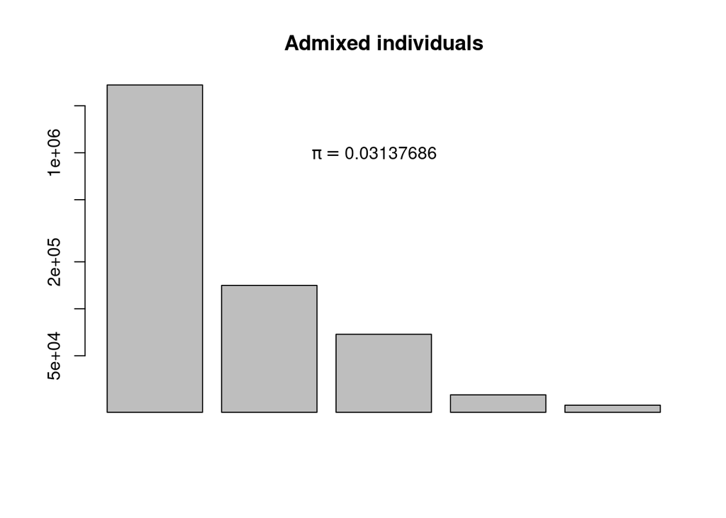

```r
Adm.sfs <- scan('hybrids.sfs',   quiet = TRUE)
Adm.n <- length(Adm.sfs) - 1
Adm.pi <- PiTajima(Adm.sfs)
barplot(Adm.sfs[1:(1 + Adm.n / 2)], main = 'Admixed individuals', log = 'y')
text(3, 1.0e+06, bquote(pi==.(Adm.pi)))
```

If admixed individuals were a population, their population-level nucleotide diversity would be that high. However, they are not, and individual heterozygosities should be calculated.

```bash
#ASM=../2023-05-15/assembly.fasta
#BAM=../2023-05-18/BAM

ASM=../2024-10-04/radloci.fa
BAM=../2024-10-04/BAM

if [ ! -d toRefHybridsSFS ]; then mkdir toRefHybridsSFS; fi
for i in $(cat hybrids.txt); do
   if [ ! -e toRefHybridsSFS/$i.sfs ]; then
      if [ ! -e toRefHybridsSFS/$i.saf.idx ]; then
         angsd -i $BAM/$i.bam \
               -anc $ASM \
               -doGlf 1 \
               -GL 1 \
               -doSaf 1 \
               -C 50 \
               -ref $ASM \
               -minQ 20 \
               -minmapQ 30 \
               -setMinDepthInd 4 \
               -out toRefHybridsSFS/$i 2> toRefHybridsSFS/$i.log
      fi
      realSFS -fold 1 \
              toRefHybridsSFS/$i.saf.idx \
              1> toRefHybridsSFS/$i.sfs \
              2>> toRefHybridsSFS/$i.log
   fi
done
find toRefHybridsSFS -name '*.gz'  -delete
find toRefHybridsSFS -name '*.idx' -delete
```

```r
library(kableExtra)
hybrids <- scan('hybrids.txt', what = 'character', quiet = TRUE)
SFSs <- lapply(paste0('toRefHybridsSFS/', hybrids, '.sfs'), scan, quiet = TRUE)
sfs  <- data.frame(
   Sample = hybrids,
   Pi = sapply(SFSs, function(x) x[2] / sum(x))
)
kable(sfs) %>% kable_styling()
```

| Sample | Pi |
| --- | --- |
| L019Cxa | 0.0206583 |
| L019Cxb | 0.0204651 |
| L088Cma | 0.0193785 |
| S023Cxd | 0.0204737 |

Individual estimates of heterozygosity are lower (half) when using reads mapped to RAD loci (not shown). The reason does not seem to be the difference in coverage. RAD loci are shorter than the reference, and twice as many reads are mapped to RAD loci than to the reference. As a result, depth of coverage is higher in RAD loci than in the reference.

## Inbreeding coeficients from alignments to the reference genome

Inbreeding coefficients per individual can be estimated with `ngsF` from genotype likelihoods (Vieira et al. 2013). Because genotype likelihoods depend only on indidivual data, and no priors are needed, I can compute them all together, without distinguishing populations.

```bash
ASM=../2023-05-15/assembly.fasta
BAM=../2023-05-18/BAM
if [ ! -e all.toRef.list ]; then
   ls -1 $BAM/*.bam > all.toRef.list
fi
if [ ! -d toRefF ]; then mkdir toRefF; fi
if [ ! -e toRefF/all.F ]; then
   if [ ! -e toRefF/all.glf ]; then
      if [ ! -e toRefF/all.glf.gz ]; then
         angsd -b all.toRef.list \
               -ref $ASM \
               -out toRefF/all \
               -doGlf 3 \
               -doHWE 1 \
               -doMajorMinor 1 \
               -GL 1 \
               -minHWEpval 0.05 \
               -minMapQ 30 \
               -minQ 20 \
               -only_proper_pairs 0 \
               -baq 1 \
               -minInd 77 \
               -setMinDepthInd 4 \
               -nThreads 8 1> toRefF/glf.log 2> toRefF/glf.err
      fi
      gunzip toRefF/all.glf.gz
   fi
   NSITES=$(tail toRefF/glf.err | grep "retained after filtering:" | gawk '{print $NF}')
   ngsF --n_ind $(cat all.toRef.list | wc -l) \
        --n_sites $NSITES \
        --glf toRefF/all.glf \
        --out toRefF/all.F
fi
```

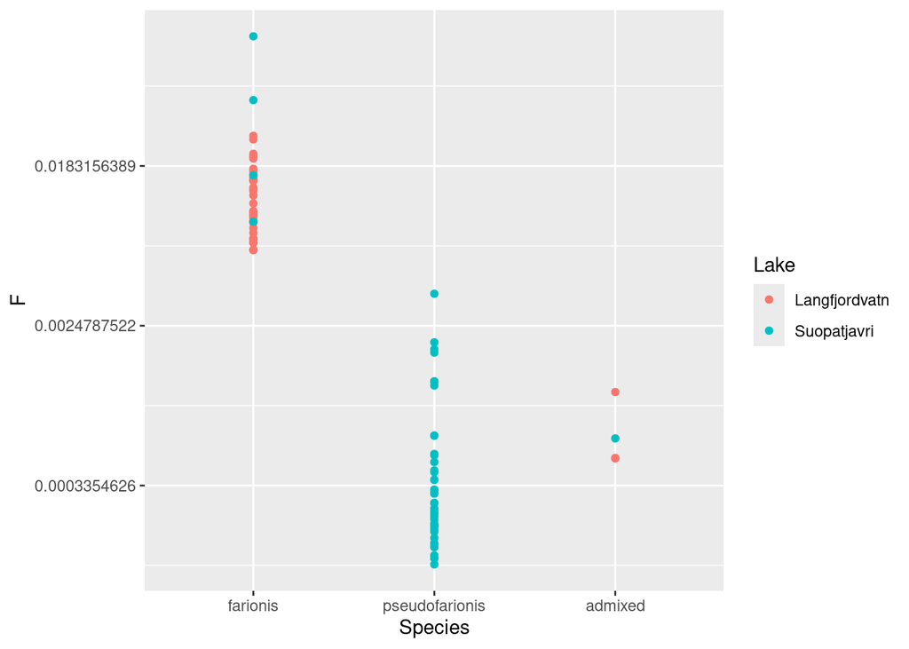

```r
library('ggplot2')
GeneticSummary <- read.table('../2024-10-05/summary.txt',
                             header = TRUE)
F <- scan('toRefF/all.F', quiet = TRUE)
Samples <- gsub('.bam', '', basename(scan('all.toRef.list', what = 'character')))
GeneticSummary$F <- F[match(GeneticSummary$Sample, Samples)]
GeneticSummary$Species <- factor('admixed', levels = c('farionis', 'pseudofarionis', 'admixed'))
GeneticSummary[GeneticSummary$K2.1 > 0.9, 'Species'] <- 'pseudofarionis'
GeneticSummary[GeneticSummary$K2.2 > 0.9, 'Species'] <- 'farionis'
ggplot(GeneticSummary, aes(x = Species, y = F, color = Lake)) +
   geom_point() + scale_y_continuous(trans = 'log')
```

The individual inbreeding coefficients are higher in *C. farionis* than in *C. pseudofarionis*. Curiously, two of the *C. farionis* individuals collected in Suopatjavri have much higher levels of inbreeding than typically observed in *C. farionis*. Admixed individuals do not have the lowest values of *F*, perhaps because of having inherited some of the inbreeding from their *C. farionis* ancestors (almost 40% of their genome).

In any case, inbreeding is overall low, as expected for a diverse, outbred population. Selfing must be rare, despite the hermaphroditic nature of these guys.

## Posterior probabilities of genotypes from alignments to the reference genome

```bash
ASM=../2023-05-15/assembly.fasta
BAM=../2023-05-18/BAM

if [ ! -d toRefPOST ]; then mkdir toRefPOST; fi
for pop in farionis pseudofarionis hybrids; do
   MININD=$(( $(cat $pop.txt | wc -l) * 4 / 5 ))
   if [ $MININD -lt 4 ]; then MININD=4; fi
   if [ ! -e toRefPOST/$pop.geno.gz ]; then
      angsd -bam $pop.toRef.list \
            -ref $ASM \
            -out toRefPOST/$pop \
            -doGeno 13 \
            -GL 1 \
            -doPost 3 \
            -doHWE 1 \
            -skipMissing 0 \
            -pest $pop.sfs \
            -doMajorMinor 1 \
            -doMaf 1 \
            -minHWEpval 0.05 \
            -minMapQ 30 \
            -minQ 20 \
            -baq 1 \
            -minInd $MININD \
            -setMinDepthInd 4 \
            -nThreads 8 1> toRefPOST/$pop.stdout 2> toRefPOST/$pop.stderr
   fi
done
```

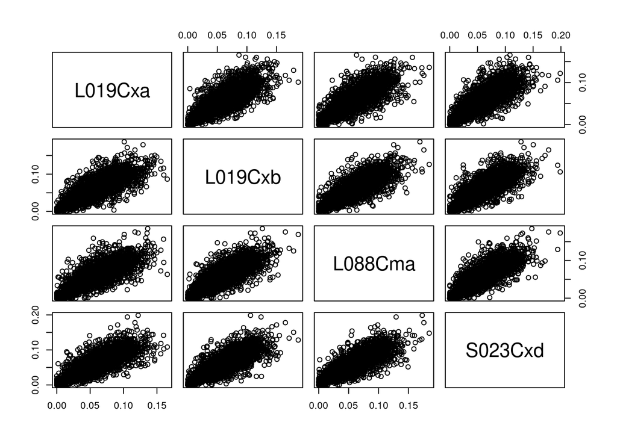

```r
library(MetBrewer)
Hyb.name <- basename(scan('hybrids.toRef.list', 'character', quiet = TRUE))
Hyb.name <- gsub('.bam', '', Hyb.name)
Hyb.geno <- read.table('toRefPOST/hybrids.geno.gz',
                       col.names = c('locus', 'pos', 'major', 'minor',
                                     paste0(rep(Hyb.name, each = 4),
                                            rep(c('.geno', '.P1', '.P2', '.P3'),
                                                length(Hyb.name)))))
LociPerContig <- table(Hyb.geno$locus)
AtLeast100 <- names(LociPerContig[LociPerContig >= 100])
Hyb.geno <- Hyb.geno[Hyb.geno$locus %in% AtLeast100,]
PerLocus.H <- lapply(
   Hyb.name,
   function(x) {
      sapply(split(Hyb.geno[, paste0(x, '.P2')], Hyb.geno$locus),
             mean)
   }
)
perLocusH <- as.data.frame(do.call(cbind, PerLocus.H))
names(perLocusH) <- Hyb.name
pairs(perLocusH)
```

After removing contigs with less than 100 loci, the positive correlations of mean contig heterozygosity among individuals are observed. I assume this reflects the fact that a considerable fraction of variation in heterozygosity along the genome is due to common underlying causes, like gene density or other selective constraints and mutational hotspots.

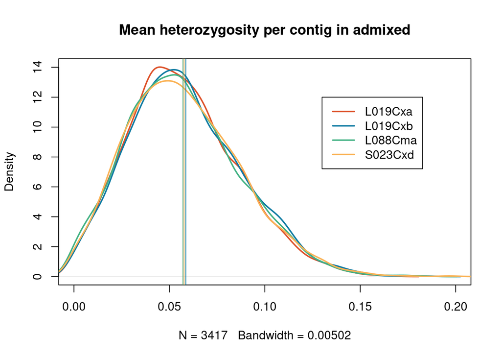

```r
c <- met.brewer('Egypt', 4)
plot(density(perLocusH$L019Cxa), col = c[1], lwd = 2,
     main = 'Mean heterozygosity per contig in admixed',
     xlim = c(0, 0.2))
lines(density(perLocusH$L019Cxb), col = c[2], lwd = 2)
lines(density(perLocusH$L088Cma), col = c[3], lwd = 2)
lines(density(perLocusH$S023Cxd), col = c[4], lwd = 2)
abline(v = apply(perLocusH, 2, mean), col = c)
legend(0.13, 12, Hyb.name, col = c, lwd = 2)
```

```r
rm(Hyb.geno, perLocusH, PerLocus.H)
```

The distribution of mean heterozygosity per contig is not bimodal: admixed individuals are not that much more heterozygous in some contigs than in others, when considering the subset of contigs with at least 100 positions genotyped, and after having filtered for Hardy-Weinberg equilibrium. Maybe we should not have applied such filter here. Another simple explanation for this unexpected result is that the contigs are in general longer than the tracts of increased heterozygosity. In addition, admixed fragments are expected to have just 12% higher heterozygosity (the $F_{ST}$), which is presumably undetectable.

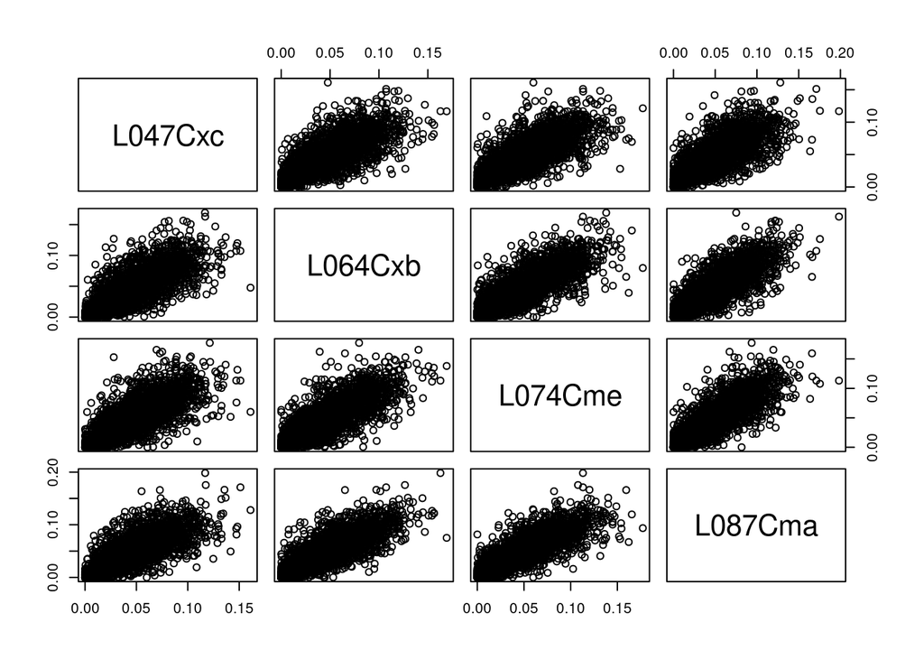

```r
far.name <- basename(scan('farionis.toRef.list', 'character', quiet = TRUE))
far.name <- gsub('.bam', '',far.name)
far.geno <- read.table('toRefPOST/farionis.geno.gz',
                       col.names = c('locus', 'pos', 'major', 'minor',
                                     paste0(rep(far.name, each = 4),
                                            rep(c('.geno', '.P1', '.P2', '.P3'),
                                                length(far.name)))))
LociPerContig <- table(far.geno$locus)
AtLeast100 <- names(LociPerContig[LociPerContig >= 100])
far.geno <- far.geno[far.geno$locus %in% AtLeast100,]
PerLocus.H <- lapply(
   far.name,
   function(x) {
      sapply(split(far.geno[, paste0(x, '.P2')], far.geno$locus),
             mean)
   }
)
perLocusH <- as.data.frame(do.call(cbind, PerLocus.H))
names(perLocusH) <- far.name
pairs(perLocusH[, sample(far.name, 4)])
```

Just a sample of 4 out of 35 *C. farionis* individuals, to make sure the correlation is not only present among admixed individuals.

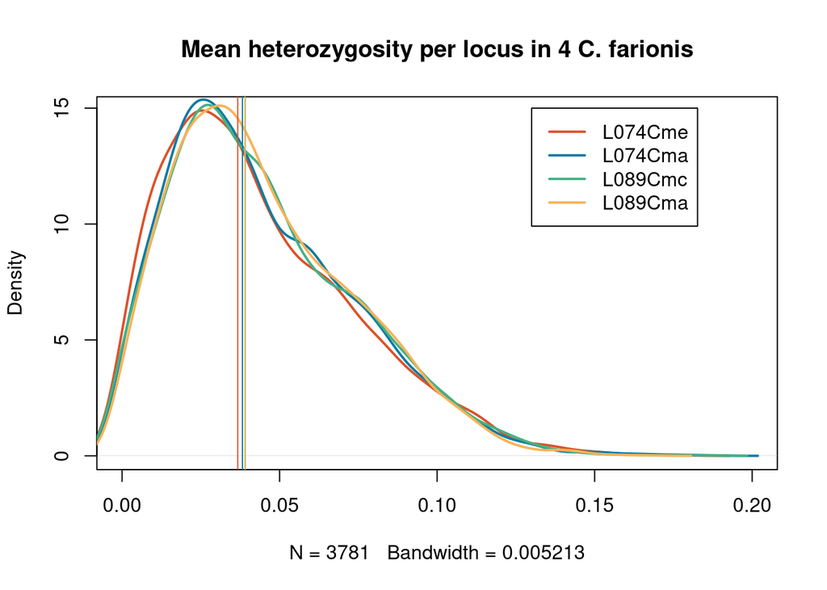

```r
i <- sample(1:length(far.name), 4)
plot(density(perLocusH[, i[1]]), col = c[1], lwd = 2,
     main = 'Mean heterozygosity per locus in 4 C. farionis',
     xlim = c(0, 0.2))
lines(density(perLocusH[, i[2]]), col = c[2], lwd = 2)
lines(density(perLocusH[, i[3]]), col = c[3], lwd = 2)
lines(density(perLocusH[, i[4]]), col = c[4], lwd = 2)
abline(v = sapply(far.name[i],
                  function(x) sum(far.geno[, paste0(x, '.P2')])/dim(far.geno)[1]),
       col = c)
legend(0.13, 15, far.name[i], col = c, lwd = 2)
```

```r
#rm(par.geno, perLocusH, PerLocus.H)
```

Vertical lines are estimated heterozygosities per individual, from the posterior probabilities, not the average of the contig mean heterozygosities.

```r
pse.name <- basename(scan('pseudofarionis.toRef.list', 'character', quiet = TRUE))
pse.name <- gsub('.bam', '',pse.name)
pse.geno <- read.table('toRefPOST/pseudofarionis.geno.gz',
                       col.names = c('locus', 'pos', 'major', 'minor',
                                     paste0(rep(pse.name, each = 4),
                                            rep(c('.geno', '.P1', '.P2', '.P3'),
                                                length(pse.name)))))
PerLocus.H <- lapply(
   pse.name,
   function(x) {
      sapply(split(pse.geno[, paste0(x, '.P2')], pse.geno$locus),
             mean)
   }
)
perLocusH <- as.data.frame(do.call(cbind, PerLocus.H))
```

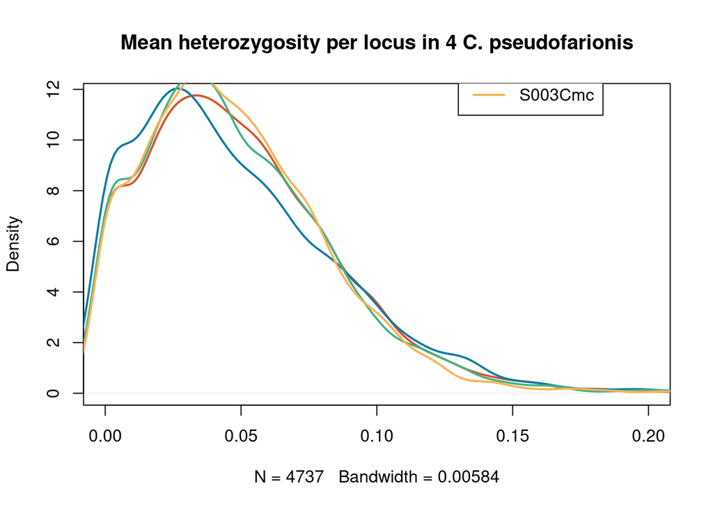

```r
i <- sample(1:length(pse.name), 4)
plot(density(perLocusH[, i[1]]), col = c[1], lwd = 2,
     main = 'Mean heterozygosity per locus in 4 C. pseudofarionis',
     xlim = c(0, 0.2))
lines(density(perLocusH[, i[2]]), col = c[2], lwd = 2)
lines(density(perLocusH[, i[3]]), col = c[3], lwd = 2)
lines(density(perLocusH[, i[4]]), col = c[4], lwd = 2)
legend(0.13, 15, pse.name[i], col = c, lwd = 2)
```

```r
rm(par.geno, perLocusH, PerLocus.H)
```

## Posterior probabilities of genotypes from alignments to ddRAD loci

```bash
ASM=../2024-10-04/radloci.fa
BAM=../2024-10-04/BAM

if [ ! -d toRadPOST ]; then mkdir toRadPOST; fi

for pop in farionis pseudofarionis hybrids; do
   if [ ! -e $pop.toRad.list ]; then
      find $BAM -name '*.bam' | grep -f $pop.txt | sort > $pop.toRad.list
   fi
done

# The SFS for hybrids must have been calculated above.
for pop in farionis pseudofarionis hybrids; do
   MININD=$(( $(cat $pop.txt | wc -l) * 4 / 5 ))
   if [ $MININD -lt 4 ]; then MININD=4; fi
   if [ ! -e toRadPOST/$pop.geno.gz ]; then
      angsd -bam $pop.toRad.list \
            -ref $ASM \
            -out toRadPOST/$pop \
            -doGeno 13 \
            -GL 1 \
            -doPost 3 \
            -doHWE 1 \
            -skipMissing 0 \
            -pest $pop.sfs \
            -doMajorMinor 1 \
            -doMaf 1 \
            -minHWEpval 1.0e-03 \
            -minMapQ 30 \
            -minQ 20 \
            -baq 1 \
            -minInd $MININD \
            -setMinDepthInd 4 \
            -nThreads 8 1> toRadPOST/$pop.stdout 2> toRadPOST/$pop.stderr
   fi
done
```

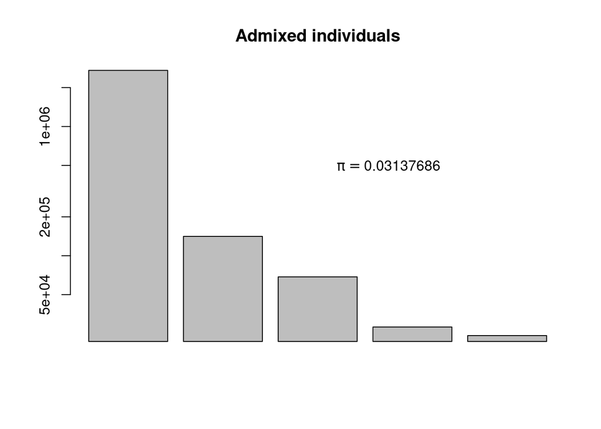

```r
library(MetBrewer)
Hyb.sfs <- scan('hybrids.sfs', quiet = TRUE)
Hyb.n <- length(Hyb.sfs) - 1
Hyb.pi <- PiTajima(Hyb.sfs)
barplot(Hyb.sfs[1:(1 + Hyb.n / 2)], main = 'Admixed individuals', log = 'y')
text(4, 5.0e+05, bquote(pi==.(Hyb.pi)))
```

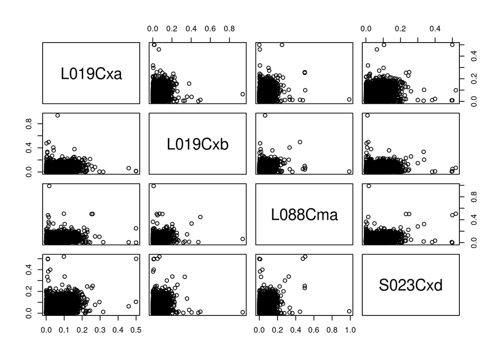

```r
Hyb.name <- basename(scan('hybrids.toRef.list', 'character', quiet = TRUE))
Hyb.name <- gsub('.bam', '', Hyb.name)
Hyb.geno <- read.table('toRadPOST/hybrids.geno.gz',
                       col.names = c('locus', 'pos', 'major', 'minor',
                                     paste0(rep(Hyb.name, each = 4),
                                            rep(c('.geno', '.P1', '.P2', '.P3'),
                                                length(Hyb.name)))))
PerLocus.H <- lapply(
   Hyb.name,
   function(x) {
      sapply(split(Hyb.geno[, paste0(x, '.P2')], Hyb.geno$locus),
             mean)
   }
)
perLocusH <- as.data.frame(do.call(cbind, PerLocus.H))
names(perLocusH) <- Hyb.name
pairs(perLocusH)
```

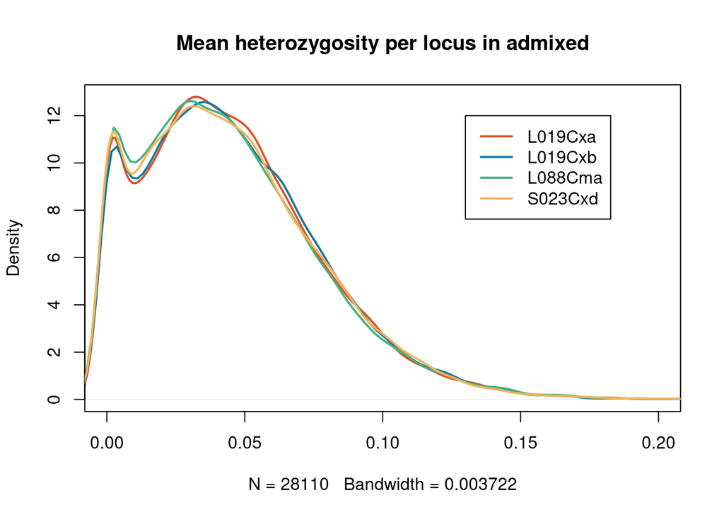

```r
c <- met.brewer('Egypt', 4)
plot(density(perLocusH$L019Cxa), col = c[1], lwd = 2,
     main = 'Mean heterozygosity per locus in admixed',
     xlim = c(0, 0.2))
lines(density(perLocusH$L019Cxb), col = c[2], lwd = 2)
lines(density(perLocusH$L088Cma), col = c[3], lwd = 2)
lines(density(perLocusH$S023Cxd), col = c[4], lwd = 2)
legend(0.13, 12, Hyb.name, col = c, lwd = 2)
```

```r
rm(Hyb.geno, perLocusH, PerLocus.H)
```

```r
far.name <- basename(scan('farionis.toRef.list', 'character', quiet = TRUE))
far.name <- gsub('.bam', '',far.name)
far.geno <- read.table('toRadPOST/farionis.geno.gz',
                       col.names = c('locus', 'pos', 'major', 'minor',
                                     paste0(rep(far.name, each = 4),
                                            rep(c('.geno', '.P1', '.P2', '.P3'),
                                                length(far.name)))))
PerLocus.H <- lapply(
   far.name,
   function(x) {
      sapply(split(far.geno[, paste0(x, '.P2')], far.geno$locus),
             mean)
   }
)
perLocusH <- as.data.frame(do.call(cbind, PerLocus.H))
```

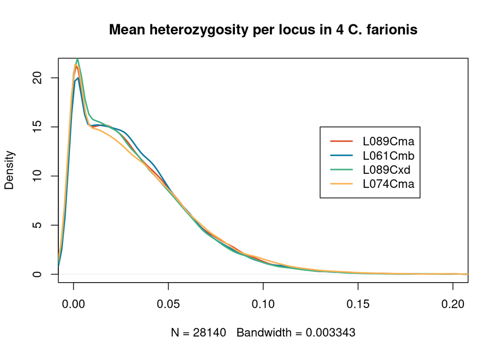

```r
i <- sample(1:length(far.name), 4)
plot(density(perLocusH[, i[1]]), col = c[1], lwd = 2,
     main = 'Mean heterozygosity per locus in 4 C. farionis',
     xlim = c(0, 0.2))
lines(density(perLocusH[, i[2]]), col = c[2], lwd = 2)
lines(density(perLocusH[, i[3]]), col = c[3], lwd = 2)
lines(density(perLocusH[, i[4]]), col = c[4], lwd = 2)
legend(0.13, 15, far.name[i], col = c, lwd = 2)
```

```r
rm(par.geno, perLocusH, PerLocus.H)
pse.name <- basename(scan('pseudofarionis.toRef.list', 'character', quiet = TRUE))
pse.name <- gsub('.bam', '',pse.name)
pse.geno <- read.table('toRadPOST/pseudofarionis.geno.gz',
                       col.names = c('locus', 'pos', 'major', 'minor',
                                     paste0(rep(pse.name, each = 4),
                                            rep(c('.geno', '.P1', '.P2', '.P3'),
                                                length(pse.name)))))
PerLocus.H <- lapply(
   pse.name,
   function(x) {
      sapply(split(pse.geno[, paste0(x, '.P2')], pse.geno$locus),
             mean)
   }
)
perLocusH <- as.data.frame(do.call(cbind, PerLocus.H))
```

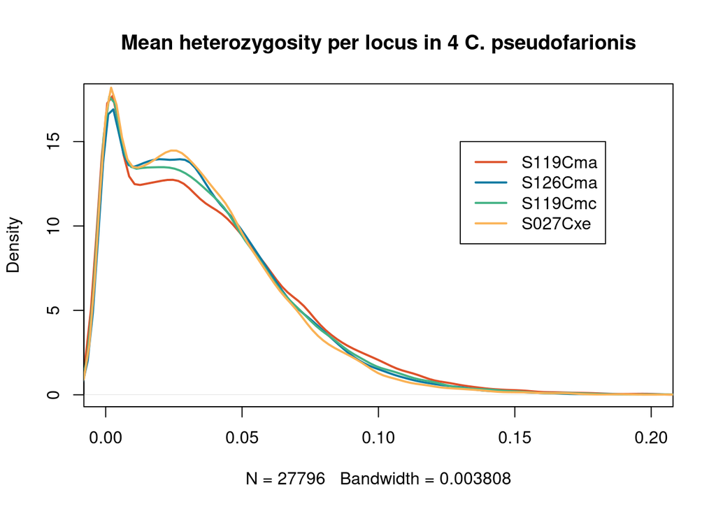

```r
i <- sample(1:length(pse.name), 4)
plot(density(perLocusH[, i[1]]), col = c[1], lwd = 2,
     main = 'Mean heterozygosity per locus in 4 C. pseudofarionis',
     xlim = c(0, 0.2))
lines(density(perLocusH[, i[2]]), col = c[2], lwd = 2)
lines(density(perLocusH[, i[3]]), col = c[3], lwd = 2)
lines(density(perLocusH[, i[4]]), col = c[4], lwd = 2)
legend(0.13, 15, pse.name[i], col = c, lwd = 2)
```

```r
rm(par.geno, perLocusH, PerLocus.H)
```

# References

Vieira, F. G., M. Fumagalli, A. Albrechtsen, and R. Nielsen. 2013. “Estimating inbreeding coefficients from NGS data: impact on genotype calling and allele frequency estimation.” *Genome Research* 23: 1852–61. https://doi.org/10.1101/gr.157388.113.

Weir, B. S., and C. C. Cockerham. 1984. “Estimating F-Statistics for the Analysis of Population Structure.” *Evolution* 38 (6): 1358–70. https://doi.org/10.1111/j.1558-5646.1984.tb05657.x.

## Apendix. $F_{ST}$ from estimated ancestral allele frequencies

On `2024-03-11` we run NGSadmix on variable sites identified from mappings to the RAD loci. K = 2 was determined as a good fit. The program not only yields the ancestry proportions of every individual (the $N \times K$ $Q$ matrix) but also the estimated allele frequencies in the ancestral populations. Thus, we can estimate the $F_{ST}$ among those presumed ancestral populations. I would do this just to check that the $F_{ST}$ estimated on `2024-10-10` between what we call *C. farionis* (most abundant in Langfjordvatn) and *C. pseudofarionis* (most abundant in Suohpatjavri), namely 0.12, is consistent with the NGSadmix analysis.

To estimate $F_{ST}$ from estimated allele frequencies, I assume Hardy-Weinberg equilibrium in all 315642 loci included in the NGSadmix analysis. Unfortunately, the number of chromosomes used in each locus to estimate allele frequencies is unknown. At most, all 90 individuals had good data, but most probably, the amount of data is variable across sites. I believe smaller sample sizes produced downwardly biased estimates. Thus, if I specify the largest possible sample sizes, I will get the largest estimates.

In any case, the (at most) 90 current individuals represent different sample sizes of the two ancestral populations assumed when $K=2$. I assume that the two ancestries are represented by population sizes proportional to the overall current fraction of the genomes inherited from them.

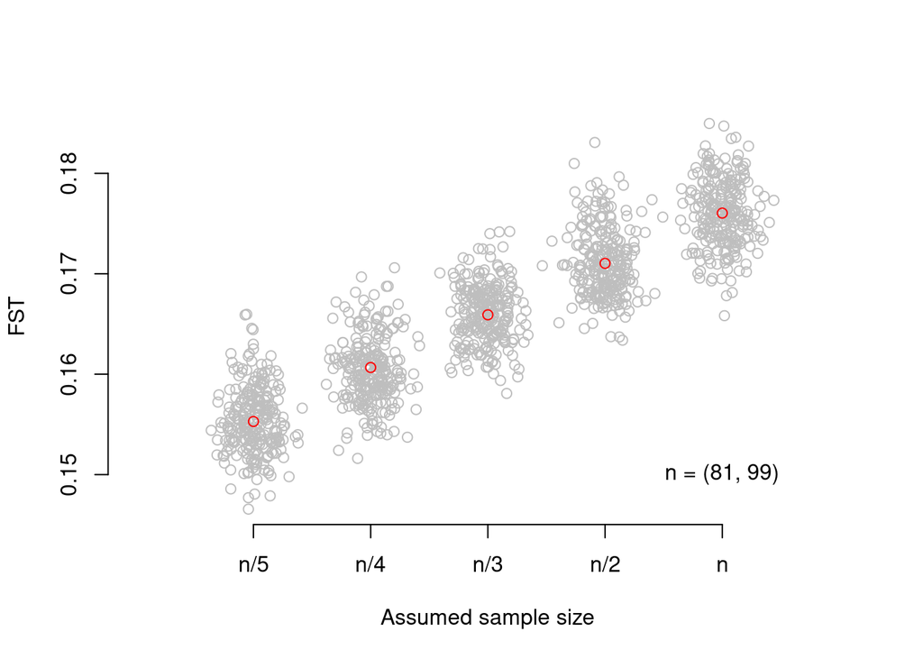

```r
source('formulas.R')
K2 <- read.table('../2024-03-11/NGSadmix/ARCTIC.K2.fopt.gz',
                 col.names = c('farionis', 'pseudofarionis'))
Q2 <- read.table('../2024-03-11/NGSadmix/ARCTIC.K2.qopt',
                 col.names = c('farionis', 'psuedofarionis'))
proportions <- colSums(Q2) / dim(Q2)[1]
# maximum number of chromosomes used to estimate frequencies:
n.max <- round(2 * dim(Q2)[1] * proportions)

NumRep <- 250
if (file.exists('FST.Rds')) {
   FST <- readRDS('FST.Rds')
} else {
   FST <- list(
      estimates = sapply(1:5, function(x) WC84w(K2, n.max / x)),
      bootstrap = sapply(1:5, function(x) {
         replicate(NumRep, WC84w(K2[sample(1:dim(K2)[1], 5000, replace = TRUE),], n.max / x))
      })
   )
   saveRDS(FST, file = 'FST.Rds')
}
plot(c(0,6), range(FST[['bootstrap']]), type = 'n',
     axes = FALSE, xlab = 'Assumed sample size',
     ylab = 'FST')
nulldev <- lapply(1:5, function(x) {
   points(rnorm(NumRep, 6 - x, 0.15), FST[['bootstrap']][,x], col = 'gray')
   points(6 - x, FST[['estimates']][x], col = 'red')
})
axis(2)
axis(1, at = 1:5, labels = c('n/5', 'n/4', 'n/3', 'n/2', 'n'))
text(5, 0.15, labels = sprintf("n = (%i, %i)", n.max[1], n.max[2]))
```

Grey dots are bootstrap pseudo-replicates, obtained with only 5000 sites.

The two ancestral populations estimated with NGSadmix on `2024-03-11` seem to have diverged to an $F_{ST} \leq 0.176$, which is higher than the 0.12 value obtained in `2024-10-10` between current populations. The difference is unlikely to be due to recent admixture, because on `2024-10-10` only non-admixed individuals were used. I assume the estimate here is higher for two reasons: first, because the algorithm in NGSadmix must maximize the differences between hypotheized ancestral populations. And second, because estimates with `realSFS` (in `2024-10-10`) may take into account the variable and limited sample size across sites, while I naively assume all loci have data in either all or a constant fraction of individuals. The smaller the fraction, the lower the estimate.